# Reproducible Data Analysis and Publishing in Chemistry with R

8/24/2019

## Welcome

- Restrooms
- Wireless internet connection
- Pre-workshop survey
- Please accept the invitation from RStudio Cloud and create an account if you have not
- Open group note-taking http://bit.ly/notesRChem

## Acknowledgement

[figure not shown]

Hosted by ACS-CINF

[figure not shown]

Sponsored by ACS Publications

## Agenda

- Test technical setup
- Learn R Basics
  - Plot a calibration curve
- Apply R to a QSAR mini-project
- Write a report with R Markdown

## Introduce yourself

- Your name
- Why are you interested in this workshop
- Anything else you’d like to share with the group

## There Are No Stupid Questions!

- Post sticky notes to the back of your laptop to signal the instructors and helpers

Hot pinky note means stop

Blue note means go

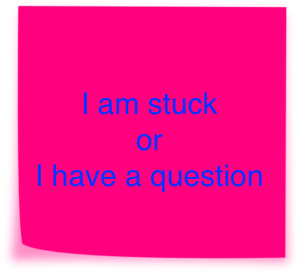

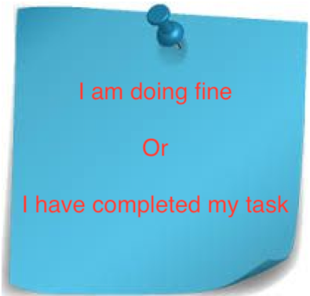

## R Basics

- Computational reproducibility and R
- R, RStudio, and RStudio Cloud overview
- Project Management in RStudio
- Basic programming in R
  - plotting a calibrarion curve
- Getting help

## NASEM Consensus Report defined Reproduciblity as Computational Reproducibility

### May 2019

- **Reproducibility**: Obtaining consistent results using the **same input data, computational steps, methods and conditions of analysis**
- **Replicability**: Obtaining consistent results across studies aimed at answering the **same scientific question**, each of which has **obtained its own data**

https://doi.org/10.17226/25303 .

[figure not shown]

## Computational Reproducibility

All the components below are required to reproduce the research publication

| The practice of distributing |  |
| --- | --- |
| All data |  |
| Software source codes or scripts for analysis |  |
| Tools (and the computing environment needed) |  |

## Automated and open workflow is good for reproducibility

Open Tools

What is it?

[figure not shown]

Programming language and the software that interprets the scripts

[figure not shown]

Integrated Development Environment (IDE) Popular way to write R scripts and interact with the R software

[figure not shown]

A managed cloud instance of RStudio. Good for teaching and learning

## RStudio / RStudio Cloud Interface

- All info needed to write code in a single window
- Shortcuts, autocompletion, and highlighting for the major file types

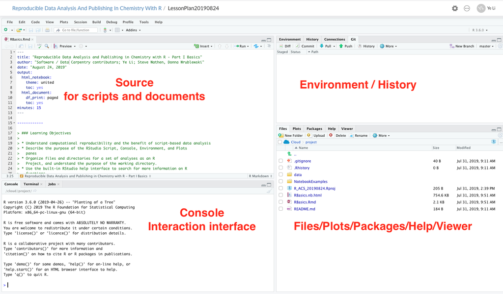

## Project management in R

### Create a self-contained project folder including a set of related data, analyses, and text that organized in subfolders

- It remembers working directory and custom settings
- Steps in **RStudio**:
  - ‘File’ menu –> click on ‘New Project’.
  - Choose ‘Existing Directory’, then browse to the folder where you downloaded workshop data files.
  - Click on ‘Create Project’. An ’ .Rproj’ file is added to the project folder.
- Steps in **RStudio Cloud**
  - Click on **‘Start’** in front of the project “Student In-Class Practice”
  - An R Project has been created for you there.

## Project management in R

### Include a set of related data, analyses, and text that organized in subfolders

- **‘data/’**: use this folder to store your raw data and intermediate datasets you may create
  - Always keep a copy of your raw data
  - do as much of your data cleanup and preprocessing with scripts
- **‘scripts/’**: use this folder for your R scripts for different analyses or plotting
- **‘figures/’**: use this folder to save figures you plot using scripts
- **‘data_output/’**: use this folder to save data files you obtained using scripts
- **‘documents/’**: use this folder for your outlines, drafts, and other texts
- Practice: in **RStudio Cloud** / Student In-Class Practices
  - Use ‘New Folder’ button in the right bottom Files section to create a solder called ‘documents’

## Project management in R

### Working directory

- **Working directory**: the place from where R will be looking for and saving the files
- RStudio will now set your **working directory** as the folder where your xxx.Rproj file lives
- Practice: in **RStudio Cloud** / Student In-Class Practices
  - Open scripts/RBasicsPractice.R
  - At line 6, typing “getwd()” and run it to identify the current working directory

## Basic R commands

### We will now use **RStudio Cloud** / Student In-Class Practices to learn:

- Use R as a calculator
- Assign value to a variable in the Environment
- Remove variables from the Environment
- Get tabulized data into the Environment as data frames
  - Calibration curve example
- Subset data frames
- Save data output
- Plot figures and linear fit
- Save plotted figures

## Slide with Plot

[figure not shown]